# Lecture 8: Intro to R - Plots Part II - ggplot2

## Recall - 4 Major Graphics Packages in R

- Base Graphics (covered last week)
- lattice (will cover today)
- ggplot (will cover today)
- grid - used by all other graphics packages

## What makes a good plot?

## Lattice Graphics

Lattice was written to provide grouping and paneling

- Consistent look and feel
- Great for multivariate data
- Takes care of lots of things for you
- Has a formula interface
- Lots of examples and support on Google
- See http://lmdvr.r-forge.r-project.org/figures/figures.html/
- Picks useful defaults for you

## Lattice Graphics

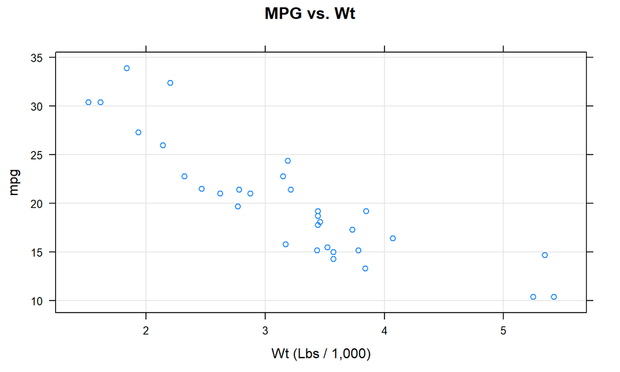

```r
library(lattice)
xlab <- "Wt (Lbs / 1,000)"
main <- "MPG vs. Wt"
xyplot(mpg~wt,data=mtcars,main=main,xlab=xlab,type=c("p","g"))
```

## Lattice Graphics - Grouping

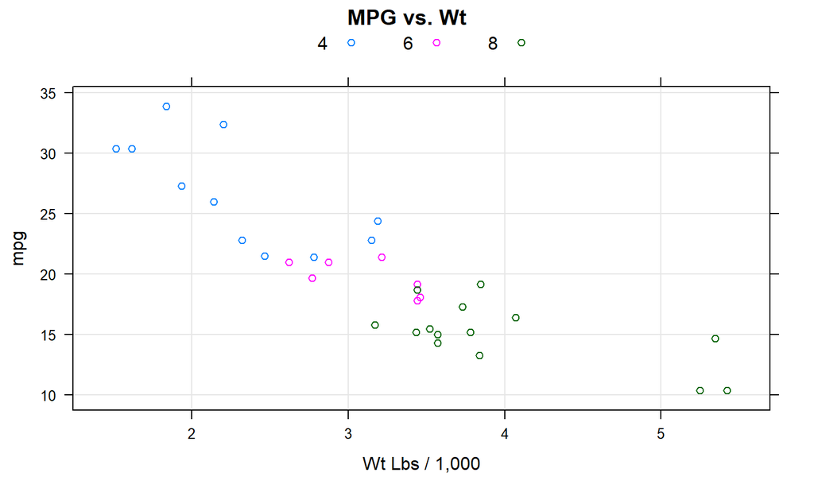

```r
library(lattice)
xlab <- "Wt Lbs / 1,000"
main <- "MPG vs. Wt"
xyplot(mpg~wt,groups=factor(cyl),data=mtcars,main=main,xlab=xlab,
       type=c("p","g"),auto.key=list(columns=3))
```

## Lattice Graphics - Panels

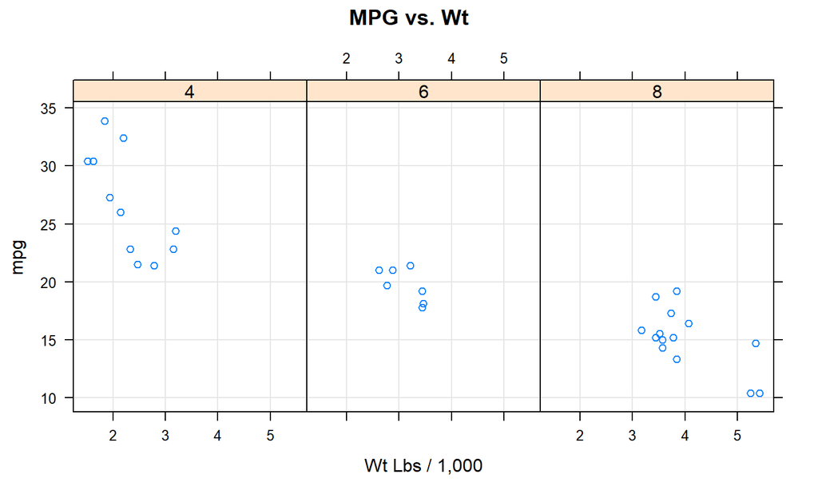

```r
library(lattice)
xlab <- "Wt Lbs / 1,000"; main <- "MPG vs. Wt"
xyplot(mpg~wt|factor(cyl),data=mtcars,main=main,xlab=xlab,
       type=c("p","g"),layout=c(3,1))
```

## Panels in Base R

A manual process: creating 3 side-by-side plots with a loop

```r
xlab <- "Wt Lbs / 1,000"; main <- "MPG vs. Wt"
par(mfrow=c(1,3))
maxmpg <- max(mtcars$mpg)
maxwt <- max(mtcars$wt)
mydf <- split(mtcars,mtcars$cyl)
for (ii in 1:length(mydf)) {
  tmpdf <- mydf[[ii]]
  main <- paste("MPG vs. Wt",names(mydf)[ii],sep=" - ")
  plot(mpg~wt,data=tmpdf,main=main,
  xlim=c(0,maxwt),
  ylim=c(0,maxmpg))
  grid()
}
```

## Panels in Base R

A manual process: creating 3 side-by-side plots with a loop

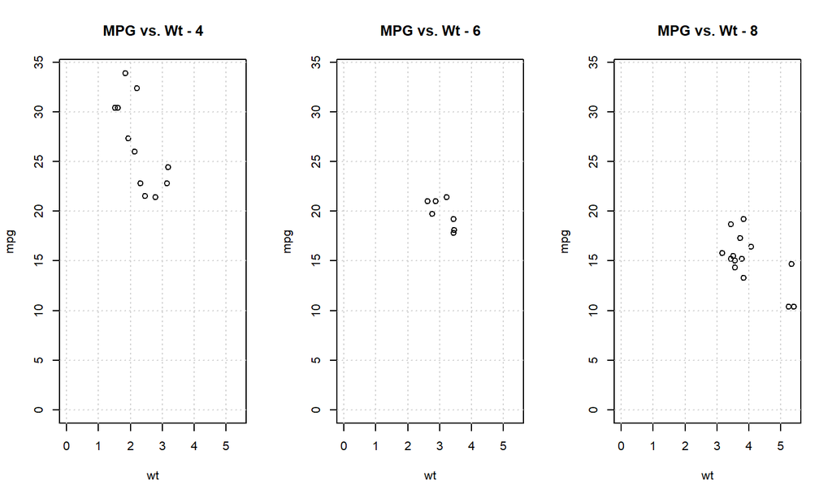

## ggplot2

- Rapidly becoming the default R graphics package
- Attempts to leverage the good parts of lattice and Base graphics
- Written according to a "Grammar of Graphics" (Wilkinson, 2005)
  - "I find myself still thinking about the book and its ideas, several weeks after I finished reading it. I love that kind of book"
  - "a richly rewarding work, an outstanding achievement by one of the leaders of statistical graphics"
  - "a pleasure to read, whether a novice or an expert in graphics"

## ggplot2 resources

- home page for ggplot: http://ggplot2.org/
- Presentation: http://ggplot2.org/resources/2007-past-present-future.pdf
- Book: ggplot2: Elegant Graphics for Data Analysis (check Amazon)
- Vanderbilt Workshop: http://ggplot2.org/resources/2007-vanderbilt.pdf
- Documentation: http://ggplot2.tidyverse.org/reference
- R for Data Science Online Book - http://r4ds.had.co.nz/
- R Graphics Cookbook: http://www.cookbook-r.com/Graphs/index.html

## ggplot2 resources

The cheat sheet is very useful!

http://www.rstudio.com/wp-content/uploads/2015/03/ggplot2-cheatsheet.pdf

## tidyverse

ggplot is part of the "tidyverse"

- A collection of R packages that share common philosophies to work well together
- Home page for project is at http://tidyverse.org/
- Main packages are: ggplot2, tibblr, tidyr, readr, purrr, dplyr
- Can install from within R Studio just like any other package
- The name of the package is simply tidyverse

## ggplot2 examples

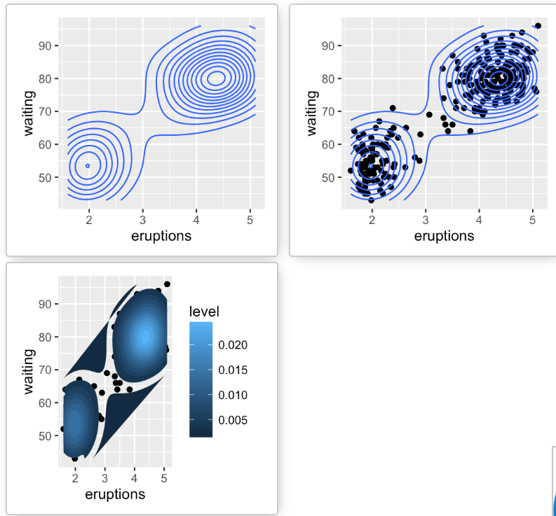

## ggplot2 examples

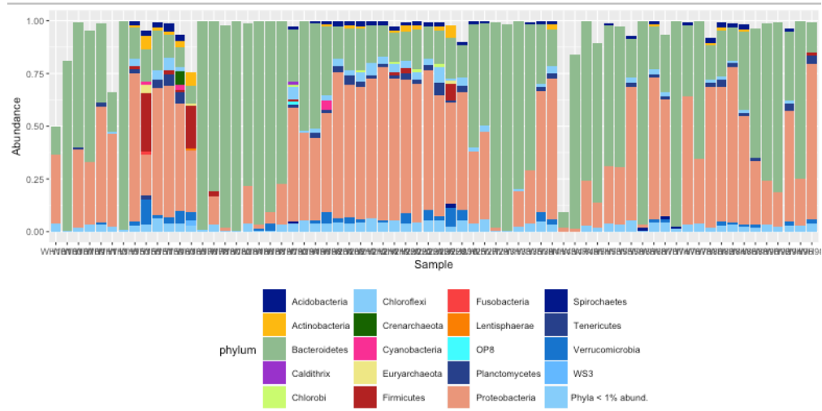

## ggplot2 examples

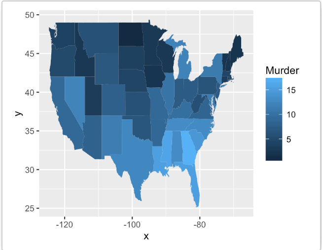

## ggplot2 - Key Ideas

These ideas come from the Grammar of Graphics

- Understanding these ideas will help you define a plot in general terms that can be implemented using ggplot commands
- Data: the actual data frame under consideration
- Aesthetics: visual elements mapped to the data (axis, lines, colors, bars, etc)
- Scales: Transformations you might want to apply (e.g. logarithm, polar coordinates)
- Geometries: The shape mapped to the aesthetic(s)

## ggplot2 - Key Ideas

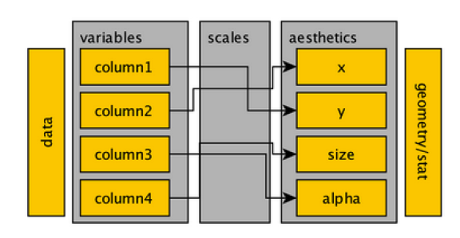

Visualizing the data, aesthetics, scales, and geometries

## Aesthetics

Here are some of the aesthetics that help make a plot:

- x and y position
- size of the elements
- shape
- color

We use geometries to view the data:

- lines and variations (dashed, segments, etc)
- bars, histograms
- text labels
- points
- http://ggplot2.tidyverse.org/reference/#section-layer-geoms

## Examples using mtcars

Let's use the simple data set mtcars to create some plots with ggplot2

A data frame with 32 observations on 11 (numeric) variables.

[, 1] mpg Miles/(US) gallon  
[, 2] cyl Number of cylinders  
[, 3] disp Displacement (cu.in.)  
[, 4] hp Gross horsepower  
[, 5] drat Rear axle ratio  
[, 6] wt Weight (1000 lbs)  
[, 7] qsec 1/4 mile time  
[, 8] vs Engine (0 = V-shaped, 1 = straight)  
[, 9] am Transmission (0 = automatic, 1 = manual)  
[,10] gear Number of forward gears  
[,11] carb Number of carburetors

## Examples using mtcars

Let's use the simple data set mtcars to create some plots with ggplot2. What are the categorical variables in this data? What are the continuous variables?

Note: We often want to compare continuous quantities across groups (categorical variables)

```r
str(mtcars)
```

```
## 'data.frame':    32 obs. of  11 variables:
##  $ mpg : num  21 21 22.8 21.4 18.7 18.1 14.3 24.4 22.8 19.2 ...
##  $ cyl : num  6 6 4 6 8 6 8 4 4 6 ...
##  $ disp: num  160 160 108 258 360 ...
##  $ hp  : num  110 110 93 110 175 105 245 62 95 123 ...
##  $ drat: num  3.9 3.9 3.85 3.08 3.15 2.76 3.21 3.69 3.92 3.92 ...
##  $ wt  : num  2.62 2.88 2.32 3.21 3.44 ...
##  $ qsec: num  16.5 17 18.6 19.4 17 ...
##  $ vs  : num  0 0 1 1 0 1 0 1 1 1 ...
##  $ am  : num  1 1 1 0 0 0 0 0 0 0 ...
##  $ gear: num  4 4 4 3 3 3 3 4 4 4 ...
##  $ carb: num  4 4 1 1 2 1 4 2 2 4 ...
```

## Plotting is all about exploring relationships!

Let's say we have the following 4 questions of interest:

- What does the distribution of wt values look like?
- Is there a relationship between mpg and wt?
- Does mpg appear to be different over individual cylinder groups?
- What are the counts of transmission types and cylinder groups?

## 1. What does the distribution of wt values look like?

- What kind of variable is wt?
- Which type of plot corresponds to that variable type and the question we want to answer?

## 1. What does the distribution of wt values look like?

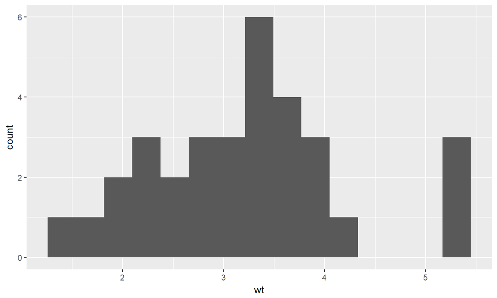

```r
library(ggplot2)
ggplot(mtcars,aes(x=wt)) + geom_histogram(bins=15)
```

## 1. What does the distribution of wt values look like?

The geometry is crucial!

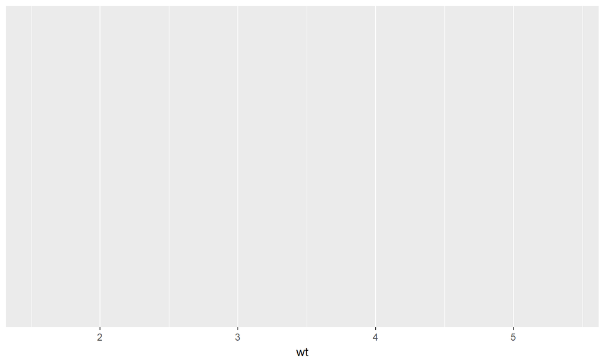

```r
library(ggplot2)
ggplot(mtcars,aes(x=wt))
```

## 2. Is there a relationship between mpg and wt?

- What kinds of variables do we have?
- Which type of plot corresponds to these variable types and the question we want to answer?

## 2. Is there a relationship between mpg and wt?

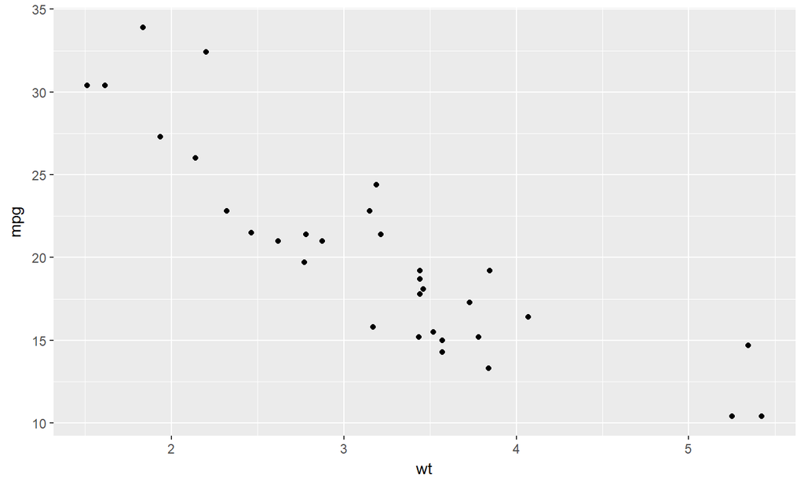

```r
ggplot(mtcars,aes(x=wt)) + geom_point(aes(y=mpg))
```

Note how we added a new geometry on an existing aesthetic mapping then added another aesthetic mapping - we mapped the y-axis to the mpg variable

## 2. Is there a relationship between mpg and wt?

We could also do this:

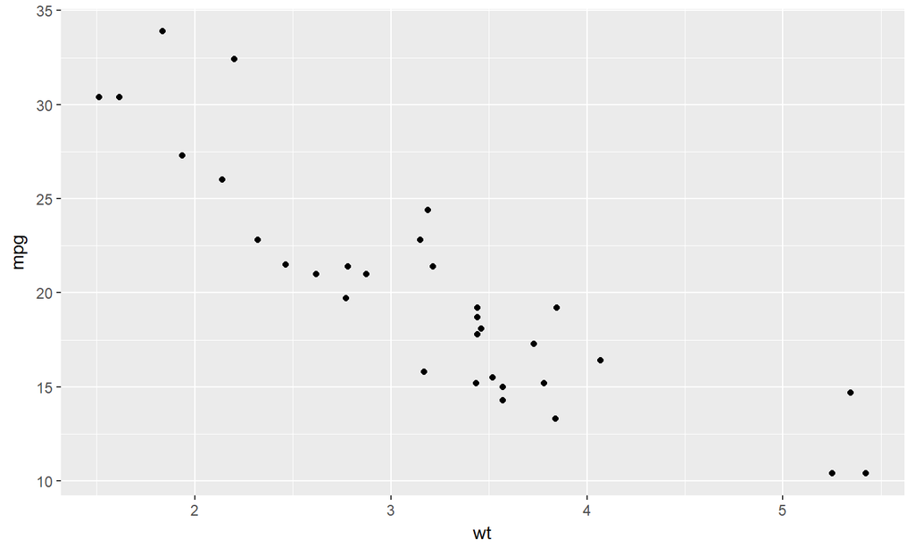

```r
ggplot(mtcars,aes(x=wt,y=mpg)) + geom_point()
```

## 2. Is there a relationship between mpg and wt?

Adding titles, labels, captions:

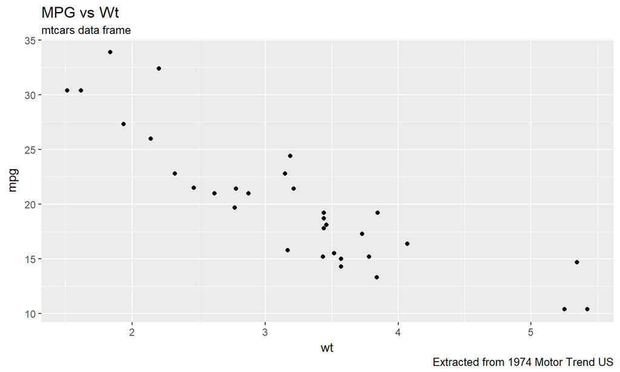

```r
ggplot(mtcars,aes(x=wt,y=mpg)) + geom_point() +
  ggtitle("MPG vs Wt","mtcars data frame") +
  labs(caption="Extracted from 1974 Motor Trend US")
```

## 2. Is there a relationship between mpg and wt?

Can also specify title in labs():

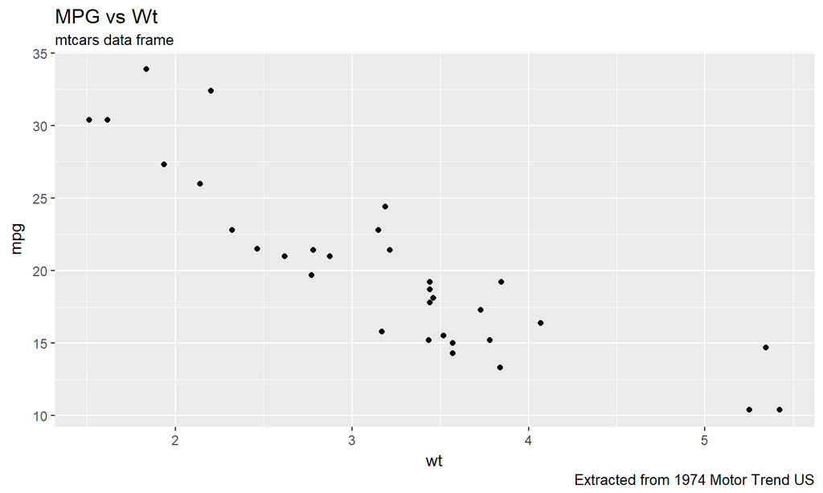

```r
ggplot(mtcars,aes(x=wt,y=mpg)) + geom_point() +
  labs(title="MPG vs Wt",subtitle="mtcars data frame",
       caption="Extracted from 1974 Motor Trend US")
```

## 2. Is there a relationship between mpg and wt?

Adding more geometry:

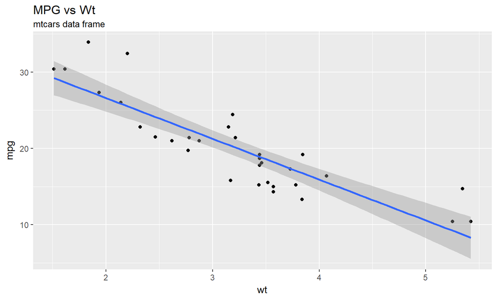

```r
ggplot(mtcars,aes(x=wt,y=mpg)) + geom_point() +
  ggtitle("MPG vs Wt","mtcars data frame") +
  geom_smooth(method="lm")
```

## 3. Does mpg appear to be different over individual cylinder groups?

- What kinds of variables do we have?
- Which type of plot corresponds to these variable types and the question we want to answer?

## 3. Does mpg appear to be different over individual cylinder groups?

- We can use color, shapes, and size to see how unique values of a factor or category impact the plot (this is called "grouping")
- Note that the cyl variable assumes 3 unique values:

```r
unique(mtcars$cyl)
```

```
## [1] 6 4 8
```

```r
#Let's make cyl an "official" factor:
mtcars$cyl <- factor(mtcars$cyl)
```

## 3. Does mpg appear to be different over individual cylinder groups?

Do you think specifying this grouping variable would be an aesthetics command or a geometry command?

## 3. Does mpg appear to be different over individual cylinder groups?

- In ggplot we use an "aesthetic mapping" to specify a grouping variable

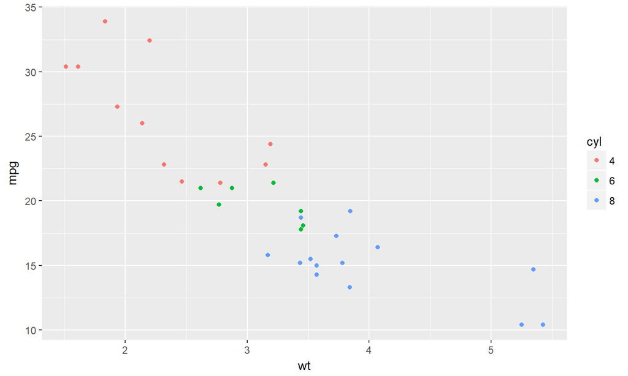

```r
ggplot(mtcars,aes(x=wt,y=mpg,color=cyl)) + geom_point()
```

## 3. Does mpg appear to be different over individual cylinder groups?

What if we use a continuous quantity as a color aesthetic?

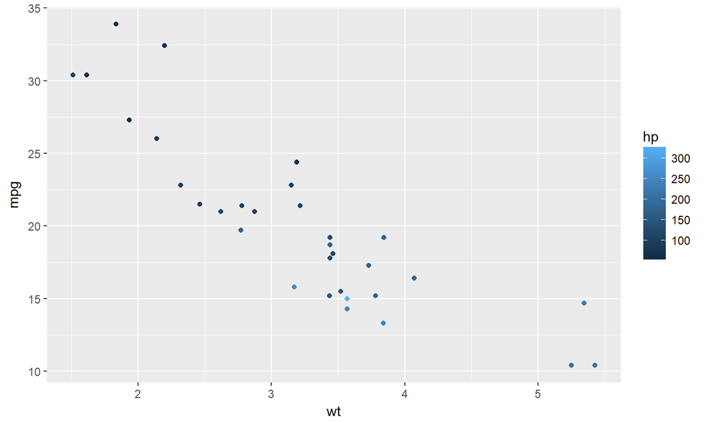

```r
ggplot(mtcars,aes(x=wt,y=mpg,color=hp)) + geom_point()
```

## 3. Does mpg appear to be different over individual cylinder groups?

We can use multiple layers for grouping. (The aesthetic command can also go inside the geometry!)

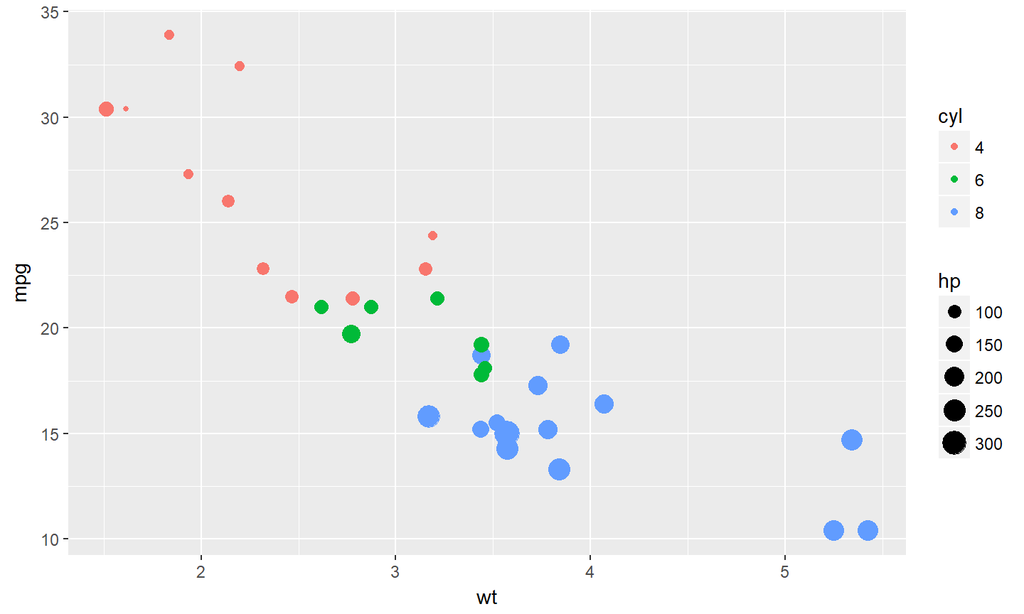

```r
ggplot(mtcars,aes(x=wt,y=mpg,color=cyl,size=hp)) + geom_point()
```

## Note the difference between mappings and settings

- Mappings are usually functions of some variable in the data
- Settings alter appearance in a "fixed" way
- Previously we used "size" as a mapping. Here it is used as a setting.

```r
library(gridExtra)
p1 <- ggplot(mtcars,aes(x=wt,y=mpg)) + geom_point(color="red")
p2 <- ggplot(mtcars,aes(x=wt,y=mpg)) + geom_point(color="red",size=4)
grid.arrange(p1, p2, nrow=1, ncol=2)
```

## Note the difference between mappings and settings

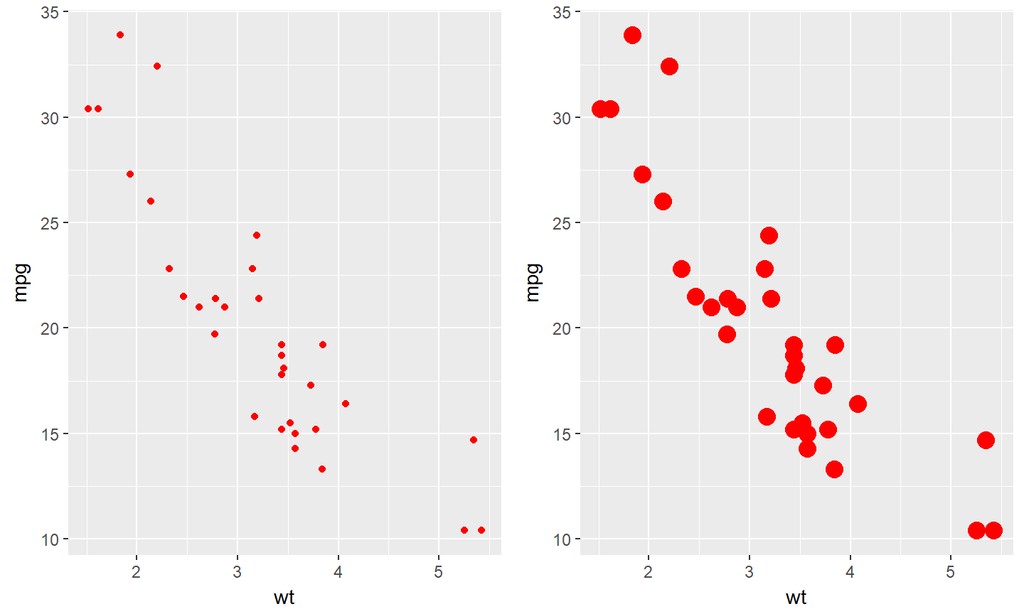

## 4. What are the counts of transmission types and cylinder groups?

To answer this, let's discuss how to handle counts and tabular data in ggplot

## Counts and Tabular Data

```r
(ctab <- table(carb=mtcars$carb))
```

```
## carb
##  1  2  3  4  6  8
##  7 10  3 10  1  1
```

```r
(df <- as.data.frame(ctab))
```

```
##   carb Freq
## 1    1    7
## 2    2   10
## 3    3    3
## 4    4   10
## 5    6    1
## 6    8    1
```

## Counts and Tabular Data

Then we can use this data frame to create a plot. (Note stat="identity" because geom_bar uses stat_count by default)

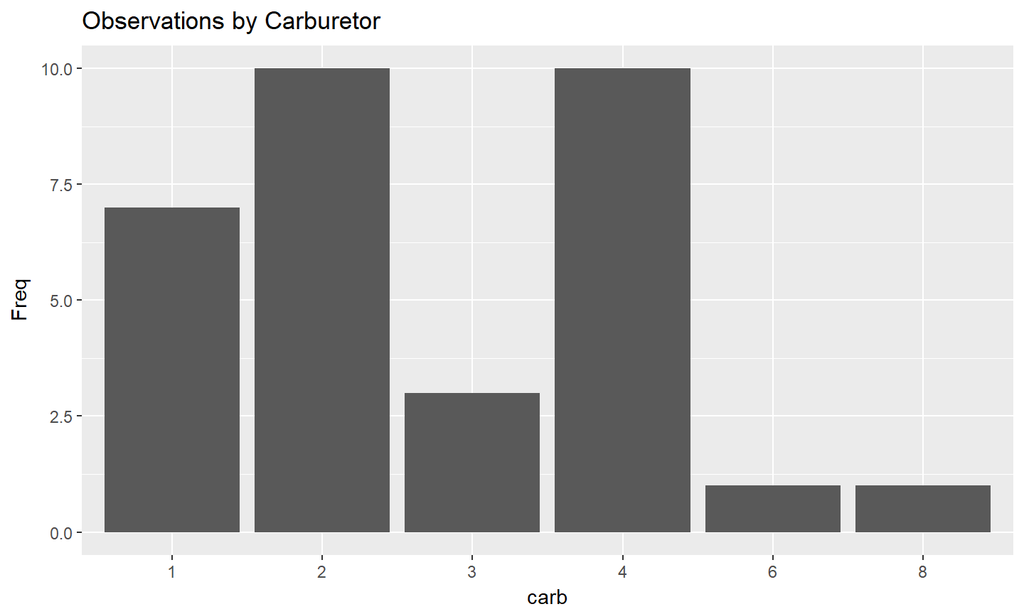

```r
ggplot(df,aes(x=carb,y=Freq)) + geom_bar(stat="identity") +
  ggtitle("Observations by Carburetor")
```

## Counts and Tabular Data

- What if we want to rearrange the bars?
- Here we want the variable "carb" in order of "Freq"

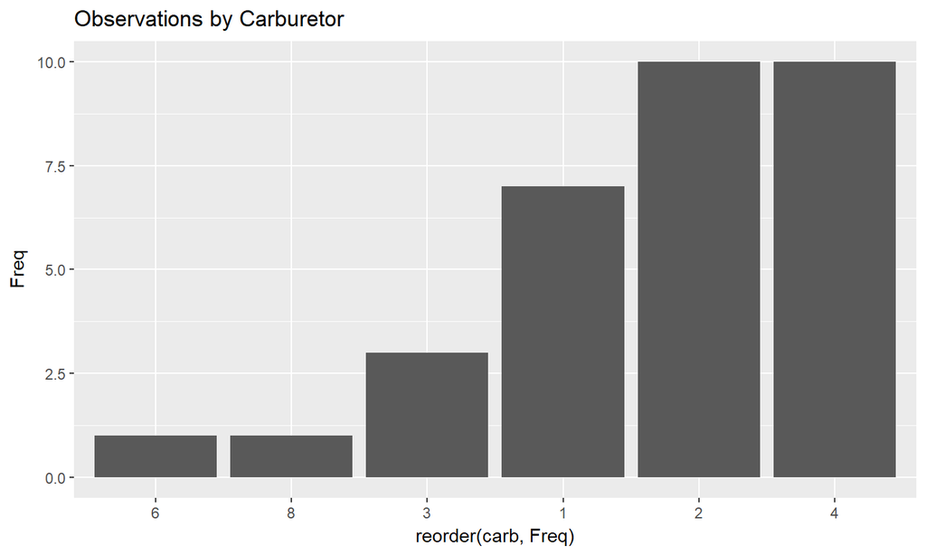

```r
ggplot(df,aes(x=reorder(carb,Freq),y=Freq)) + geom_bar(stat="identity") +
  ggtitle("Observations by Carburetor")
```

## 4. What are the counts of transmission types and cylinder groups?

- In this case, we already have the data frame. We can use the "fill" aesthetic for the factor variable "cyl"
- Similar to the "grouping" we did earlier, but over a factor variable

```r
ggplot(mtcars,aes(x=am)) + geom_bar(aes(fill=factor(cyl))) +
  ggtitle("Transmission by Cylinder Group") +
  xlab("Transmission Type") +
  ylab("Count by Cylinder Group")
```

## 4. What are the counts of transmission types and cylinder groups?

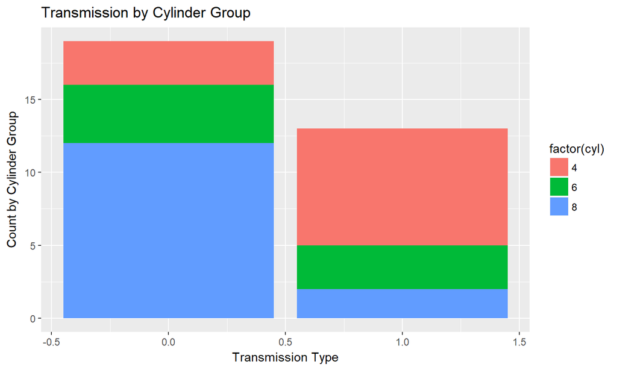

## 4. What are the counts of transmission types and cylinder groups?

- To have the bars side by side, create factor variables
- position="dodge" adjusts the horizontal positioning of the bars (compare to position="dodge2")

```r
mtcars <- transform(mtcars,am=factor(am,labels=c("Auto","Manual"
    )),cyl=factor(cyl))
    ggplot(mtcars,aes(x=am)) +
    geom_bar(aes(fill=cyl),position="dodge")
```

## 4. What are the counts of transmission types and cylinder groups?

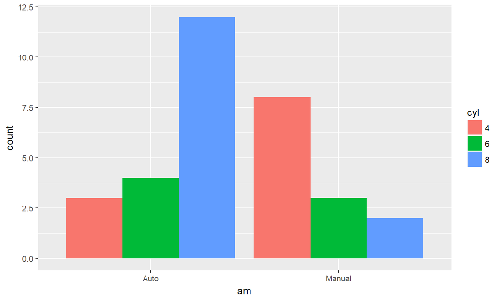

## A few more fun things

- Facets (panels for ggplot)
- density and color fill
- boxplots

## Facets

- Equivalent to paneling in lattice

Consider the following example with the diamonds data set (without facets):

```r
ggplot(diamonds,aes(x=carat,y=price)) +
geom_point(aes(color=clarity)) +
ggtitle("Price vs Carat Size")
```

## Facets

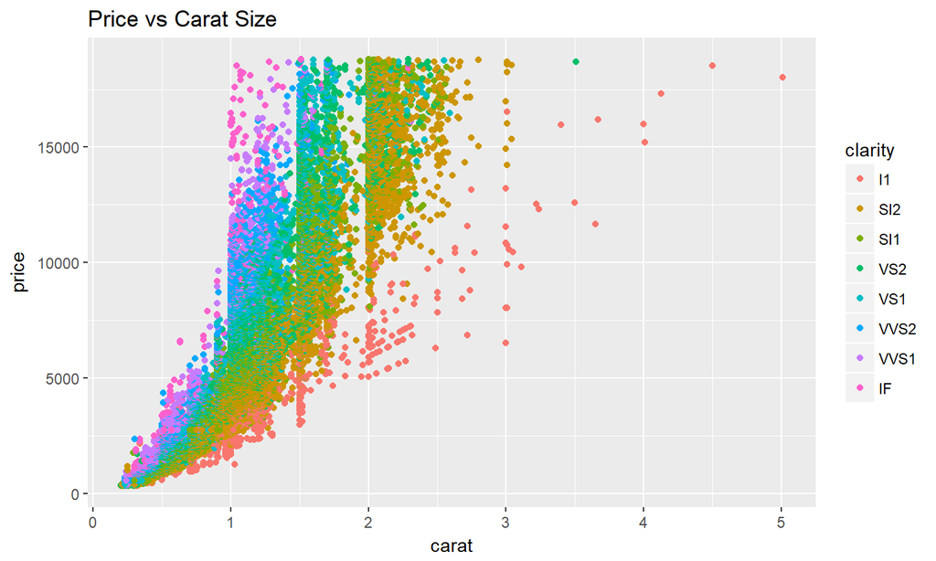

Hard to read and interpret!

## Facets

- The facet_wrap() is used to break down a large plot into multiple small plots for individual categories. It takes a formula as the main argument. The items to the left of ~ forms the rows while those to the right form the columns.

```r
ggplot(diamonds,aes(x=carat,y=price)) +
geom_point() +
facet_wrap(~clarity)
```

## Facets

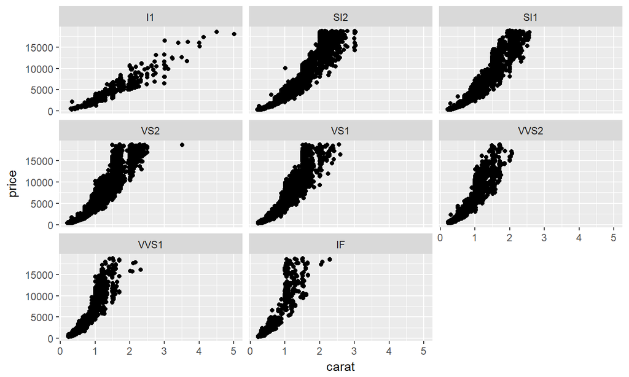

## Facets

- The facet_wrap() is used to break down a large plot into multiple small plots for individual categories. It takes a formula as the main argument. The items to the left of ~ forms the rows while those to the right form the columns.

```r
ggplot(diamonds,aes(x=carat,y=price)) +
geom_point() +
facet_wrap(cut~clarity)
```

## Facets

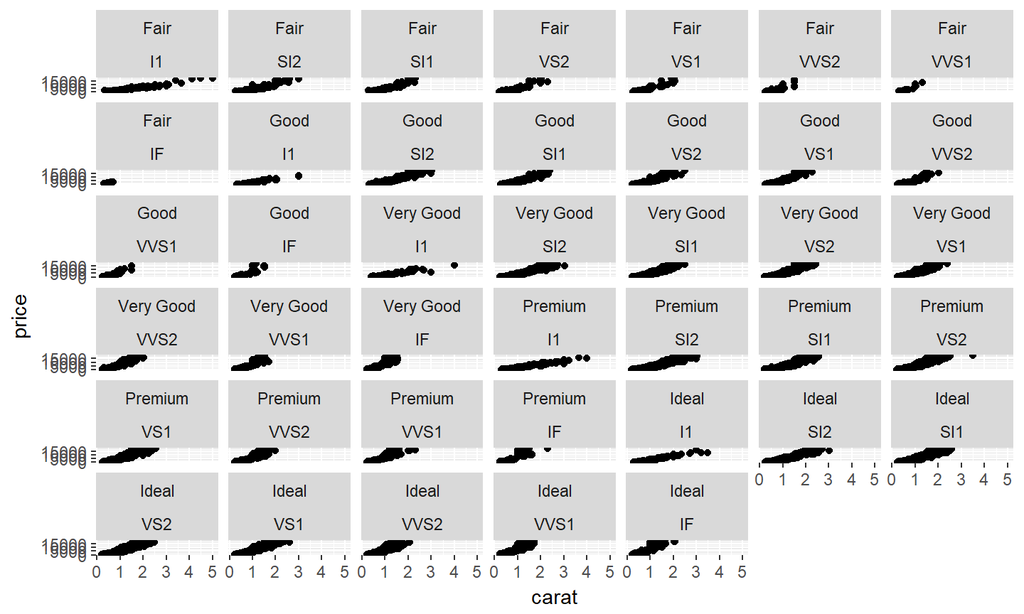

## Facets

But let's not leave out the pretty colors…

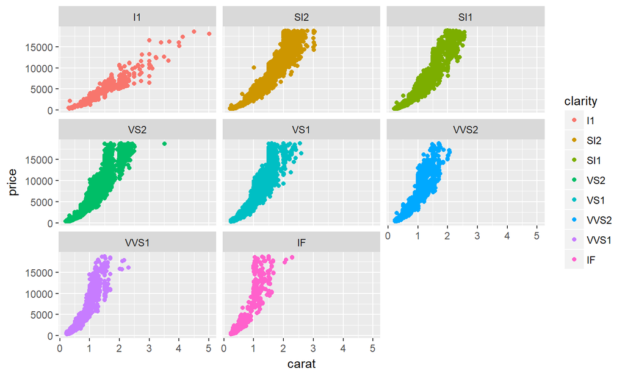

```r
ggplot(diamonds,aes(x=carat,y=price)) +
geom_point(aes(color=clarity)) +
facet_wrap(~clarity)
```

## Density

In general anything you wish to set to a static value should be set outside of the aes function

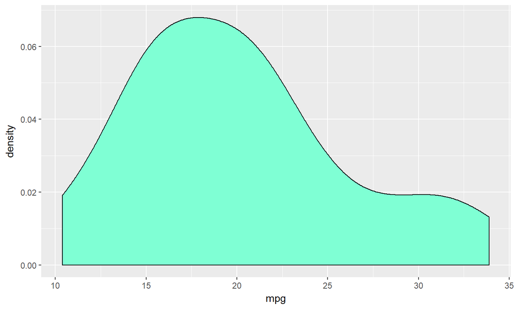

```r
ggplot(mtcars) + geom_density(aes(x=mpg),fill="aquamarine")
```

## Density

We can group the density (fill moves inside the aes function):

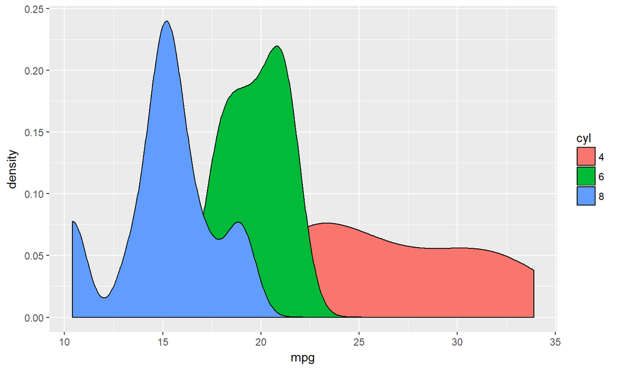

```r
ggplot(mtcars) + geom_density(aes(x=mpg,fill=cyl))
```

## Boxplot

A boxplot of mpg across cylinder groups:

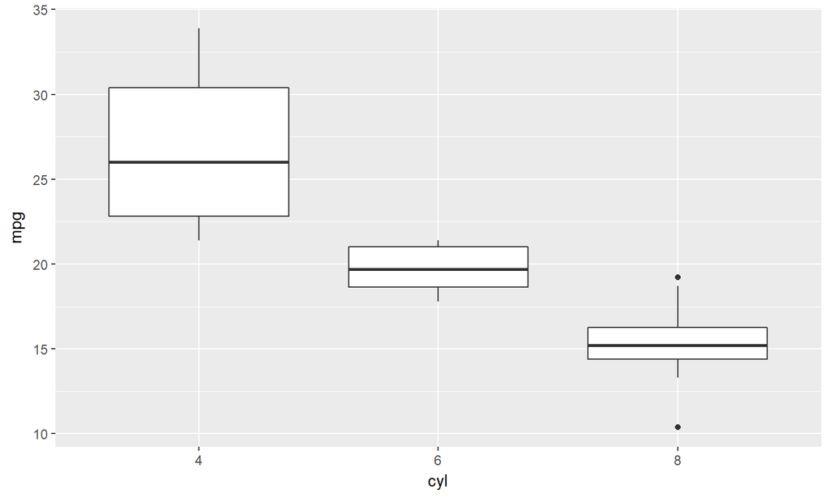

```r
ggplot(mtcars) + geom_boxplot(aes(x=cyl,y=mpg))
```

## Summary of ggplot geometry

- One continuous variable
  - geom_density
  - geom_histogram
- Two continuous variables
  - geom_point
  - geom_smooth
- One discrete variable + one continuous variable
  - geom_boxplot
  - geom_bar
- See the ggplot2 cheat sheet for many other geometry options!

## References

- http://r-statistics.co/Complete-Ggplot2-Tutorial-Part2-Customizing-Theme-With-R-Code.html#5.%20Faceting:%20Draw%20multiple%20plots%20within%20one%20figure/
- http://www.sthda.com/english/wiki/be-awesome-in-ggplot2-a-practical-guide-to-be-highly-effective-r-software-and-data-visualization/
- https://ggplot2.tidyverse.org/reference/position_dodge.html/